# GEICO - Mini Project : MARS models

Giovanni Fossati

# PRELIMINARIES

## Loading the data sets (previously saved)

```r
datasets_list <- c("0a", "0b", 1:5)
for( i in datasets_list ) {
    dd <- readRDS(paste0("./data/data", i, "_packed.RDS"))
    assign(paste0("data", i, ".train"), dd$train)
    assign(paste0("data", i, ".test"), dd$test)
    rm(dd)
}
```

# MARS w/ `data0a`

We fit `data0a` using R’s `earth()` function. The summary is shown below.

```r
MARS0a.train <- data0a.train
MARS0a.test <-  data0a.test

# MARS wants factors
MARS0a.train$Call_Flag <- ifelse(MARS0a.train$Call_Flag, "YES", "NO") %>% factor( . )
MARS0a.test$Call_Flag  <- ifelse(MARS0a.test$Call_Flag, "YES", "NO") %>% factor( . )

MARS0a.train$MART_STATUS <- factor(MARS0a.train$MART_STATUS)
MARS0a.test$MART_STATUS <- factor(MARS0a.test$MART_STATUS)
MARS0a.train$GENDER <- factor(MARS0a.train$GENDER)
MARS0a.test$GENDER <- factor(MARS0a.test$GENDER)
MARS0a.train$CustomerSegment <- factor(MARS0a.train$CustomerSegment)
MARS0a.test$CustomerSegment <- factor(MARS0a.test$CustomerSegment)
```

```r
MARS0a.model <- earth(Call_Flag ~ ., data = MARS0a.train, degree = 2, nfold = 5, ncross = 6, keepxy = TRUE)
```

```r
summary(MARS0a.model)
# Call: earth(formula=Call_Flag~., data=MARS0a.train, keepxy=TRUE, ncross=6, nfold=5, degree=2)
#
#                                       coefficients
# (Intercept)                             0.32142778
# RECENT_PAYMENT                         -0.24916015
# h(CHANNEL1_6M-1)                        0.01285096
# h(6-CHANNEL4_6M)                       -0.05147175
# h(3-PAYMENTS_6M)                        0.06680848
# h(PAYMENTS_6M-3)                       -0.02872144
# h(1-EVENT2_90_SUM)                      0.12216796
# h(EVENT2_90_SUM-1)                     -0.06000367
# h(6-CHANNEL4_6M) * RECENT_PAYMENT       0.04137782
# h(1-CHANNEL1_6M) * h(CHANNEL4_3M-1)     0.05090113
# h(1-CHANNEL1_6M) * h(1-CHANNEL4_3M)     0.00887860
# h(2-CHANNEL2_6M) * h(6-CHANNEL4_6M)    -0.00167514
# h(1-CHANNEL2_6M) * h(3-PAYMENTS_6M)    -0.04328597
# h(CHANNEL2_6M-1) * h(3-PAYMENTS_6M)    -0.03459738
# h(1-CHANNEL4_6M) * h(3-PAYMENTS_6M)    -0.05983306
# h(CHANNEL4_6M-1) * h(3-PAYMENTS_6M)     0.11305139
# h(4-CHANNEL4_6M) * h(PAYMENTS_6M-3)     0.00663201
# h(CHANNEL4_6M-4) * h(PAYMENTS_6M-3)     0.00175494
# h(6-CHANNEL4_6M) * h(EVENT2_90_SUM-1)   0.01262692
# h(6-CHANNEL4_6M) * h(1-EVENT2_90_SUM)  -0.01922552
# h(3-PAYMENTS_6M) * h(CHANNEL4_3M-1)    -0.22005368
# h(3-PAYMENTS_6M) * h(1-CHANNEL4_3M)     0.05225038
#
# Selected 22 of 26 terms, and 7 of 87 predictors
# Termination condition: RSq changed by less than 0.001 at 26 terms
# Importance: CHANNEL4_6M, PAYMENTS_6M, RECENT_PAYMENT, CHANNEL2_6M, CHANNEL1_6M, CHANNEL4_3M, ...
# Number of terms at each degree of interaction: 1 7 14
# GCV 0.03055956  RSS 2762.188  GRSq 0.1323095  RSq 0.133316  CVRSq 0.1280033
#
# Note: the cross-validation sd's below are standard deviations across folds
#
# Cross validation:   nterms 22.23 sd 3.60    nvars 8.63 sd 1.03
#
#      CVRSq    sd     ClassRate sd     MaxErr   sd
#       0.13 0.009          0.96  0        1.5 0.14
```

#### Important Variables

```r
ev <- evimp(MARS0a.model)
tmp.df <- data.frame(nsubsets = ev[, 3], gcv = ev[, 4], rss = ev[, 6])
row.names(tmp.df) <- sprintf('**%s**', row.names(tmp.df))
```

Important Variables (based on CV)

|  | nsubsets | gcv | rss |
| --- | --- | --- | --- |
| **CHANNEL4_6M** | 21 | 100.00 | 100.00 |
| **PAYMENTS_6M** | 20 | 60.76 | 61.12 |
| **RECENT_PAYMENT** | 18 | 50.26 | 50.70 |
| **CHANNEL2_6M** | 16 | 40.14 | 40.70 |
| **CHANNEL1_6M** | 14 | 34.35 | 34.94 |
| **CHANNEL4_3M** | 14 | 34.35 | 34.94 |
| **EVENT2_90_SUM** | 14 | 33.33 | 33.95 |

### Prediction on Test set

Setting a **threshold** on the response at **0.2**

```r
MARS0a.test.predict <- predict(MARS0a.model, newdata = MARS0a.test, type = "response")

MARS0a.test.performance <- prepare_cmat_performance(predicted = MARS0a.test.predict > MARS0a.threshold, truth = MARS0a.test$Call_Flag)
MARS0a.test.cmat <- MARS0a.test.performance$cmatrix
MARS0a.test.accuracy <- MARS0a.test.performance$accuracy

MARS0a.ROCR_pred_test <- prediction(MARS0a.test.predict, MARS0a.test$Call_Flag)
MARS0a.perf <- performance(MARS0a.ROCR_pred_test, "tpr", "fpr")
MARS0a.AUC <- as.numeric(performance(MARS0a.ROCR_pred_test, "auc")@y.values)

MARS0a.test.performance$AUC <- MARS0a.AUC
```

- With a threshold at **0.2** the *out-of-sample* confusion matrix for this fit and train/test sets is:

MARS0a Confusion Matrix (threshold = 0.2)

|  | NO | YES |
| --- | --- | --- |
| FALSE | 36151 | 944 |
| TRUE | 1215 | 473 |

The **Area Under the Curve** (**AUC**) for this model on the test data is **0.8403**, which means that our model can differentiate between a randomly selected *retained* and *non-retained* user about **84.03%** of the times.

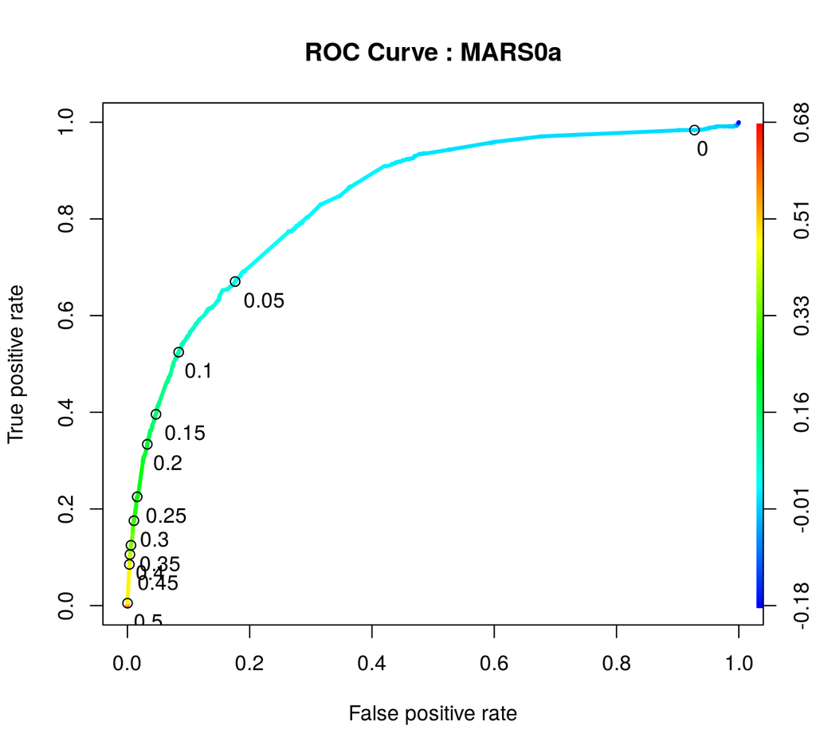

```r
# cutoffs <- seq(0.0, 1.0, by = 0.1)
cutoffs <- seq(0.0, 0.5, by = 0.05)
t.adj <- c(-0.2, 1.7)
str_title <- paste0("ROC Curve : MARS0a")
plot(MARS0a.perf, main = str_title, lwd = 3, colorize = TRUE, print.cutoffs.at = cutoffs, text.adj = t.adj)
```

```r
flag_ext <- TRUE

# perf_vs_threshold <- list()
perf_vs_threshold <- list(AUC = MARS0a.AUC)
i <- 1
for( threshold in seq(0.05, 0.4, by = 0.05)) {
    i <- i + 1
    this_model <- MARS0a.model
    this_test_data <- MARS0a.test
    this_test_predict <- predict(this_model, type = "response", newdata = this_test_data)

    perf_vs_threshold[[i]] <- prepare_cmat_performance(predicted = this_test_predict,
                                                       threshold = threshold,
                                                       truth = this_test_data$Call_Flag)
    names(perf_vs_threshold)[i] <- paste0("thr_", sprintf("%4.2f", threshold))
    if( i == 2 ) {
        perf_vs_threshold.table <- print_cmat_performance(perf_vs_threshold[[i]], errors = FALSE, extended = flag_ext, direction = "h")
    } else {
        perf_vs_threshold.table <- rbind(perf_vs_threshold.table,
                                         print_cmat_performance(perf_vs_threshold[[i]], errors = FALSE, extended = flag_ext, direction = "h"))
    }
    perf_vs_threshold[[i]]$AUC <- MARS0a.AUC
}
MARS0a.perf_vs_threshold <- perf_vs_threshold
MARS0a.perf_vs_threshold$table <- perf_vs_threshold.table
MARS0a.perf_vs_threshold$table$Threshold <- sprintf("**%.2f**", MARS0a.perf_vs_threshold$table$Threshold)
kable(MARS0a.perf_vs_threshold$table, digits = 3, align = "c", caption = "MARS0a Performance Measures vs. Threshold for Classification")
```

MARS0a Performance Measures vs. Threshold for Classification

| Threshold | Accuracy | Sensitivity | Specificity | Precision | NPV | F1 Score |
| --- | --- | --- | --- | --- | --- | --- |
| **0.05** | 0.818 | 0.670 | 0.824 | 0.126 | 0.985 | 0.212 |
| **0.10** | 0.902 | 0.524 | 0.916 | 0.192 | 0.981 | 0.281 |
| **0.15** | 0.933 | 0.396 | 0.953 | 0.244 | 0.977 | 0.302 |
| **0.20** | 0.944 | 0.334 | 0.967 | 0.280 | 0.975 | 0.305 |
| **0.25** | 0.956 | 0.225 | 0.984 | 0.347 | 0.971 | 0.273 |
| **0.30** | 0.960 | 0.176 | 0.989 | 0.385 | 0.969 | 0.241 |
| **0.35** | 0.962 | 0.125 | 0.994 | 0.447 | 0.968 | 0.195 |
| **0.40** | 0.963 | 0.105 | 0.996 | 0.490 | 0.967 | 0.173 |

# MARS w/ `data0b`

We fit `data0b` using R’s `earth()` function. The summary is shown below.

```r
MARS0b.train <- data0b.train
MARS0b.test <-  data0b.test

# MARS wants factors
MARS0b.train$Call_Flag <- ifelse(MARS0b.train$Call_Flag, "YES", "NO") %>% factor( . )
MARS0b.test$Call_Flag  <- ifelse(MARS0b.test$Call_Flag, "YES", "NO") %>% factor( . )

MARS0b.train$MART_STATUS <- factor(MARS0b.train$MART_STATUS)
MARS0b.test$MART_STATUS <- factor(MARS0b.test$MART_STATUS)
MARS0b.train$GENDER <- factor(MARS0b.train$GENDER)
MARS0b.test$GENDER <- factor(MARS0b.test$GENDER)
MARS0b.train$CustomerSegment <- factor(MARS0b.train$CustomerSegment)
MARS0b.test$CustomerSegment <- factor(MARS0b.test$CustomerSegment)
```

```r
MARS0b.model <- earth(Call_Flag ~ ., data = MARS0b.train, degree = 2, nfold = 5, ncross = 6, keepxy = TRUE)
```

```r
summary(MARS0b.model)
# Call: earth(formula=Call_Flag~., data=MARS0b.train, keepxy=TRUE, ncross=6, nfold=5, degree=2)
#
#                                       coefficients
# (Intercept)                             0.32142778
# RECENT_PAYMENT                         -0.24916015
# h(CHANNEL1_6M-1)                        0.01285096
# h(6-CHANNEL4_6M)                       -0.05147175
# h(3-PAYMENTS_6M)                        0.06680848
# h(PAYMENTS_6M-3)                       -0.02872144
# h(1-EVENT2_90_SUM)                      0.12216796
# h(EVENT2_90_SUM-1)                     -0.06000367
# h(6-CHANNEL4_6M) * RECENT_PAYMENT       0.04137782
# h(1-CHANNEL1_6M) * h(CHANNEL4_3M-1)     0.05090113
# h(1-CHANNEL1_6M) * h(1-CHANNEL4_3M)     0.00887860
# h(2-CHANNEL2_6M) * h(6-CHANNEL4_6M)    -0.00167514
# h(1-CHANNEL2_6M) * h(3-PAYMENTS_6M)    -0.04328597
# h(CHANNEL2_6M-1) * h(3-PAYMENTS_6M)    -0.03459738
# h(1-CHANNEL4_6M) * h(3-PAYMENTS_6M)    -0.05983306
# h(CHANNEL4_6M-1) * h(3-PAYMENTS_6M)     0.11305139
# h(4-CHANNEL4_6M) * h(PAYMENTS_6M-3)     0.00663201
# h(CHANNEL4_6M-4) * h(PAYMENTS_6M-3)     0.00175494
# h(6-CHANNEL4_6M) * h(EVENT2_90_SUM-1)   0.01262692
# h(6-CHANNEL4_6M) * h(1-EVENT2_90_SUM)  -0.01922552
# h(3-PAYMENTS_6M) * h(CHANNEL4_3M-1)    -0.22005368
# h(3-PAYMENTS_6M) * h(1-CHANNEL4_3M)     0.05225038
#
# Selected 22 of 26 terms, and 7 of 80 predictors
# Termination condition: RSq changed by less than 0.001 at 26 terms
# Importance: CHANNEL4_6M, PAYMENTS_6M, RECENT_PAYMENT, CHANNEL2_6M, CHANNEL1_6M, CHANNEL4_3M, ...
# Number of terms at each degree of interaction: 1 7 14
# GCV 0.03055956  RSS 2762.188  GRSq 0.1323095  RSq 0.133316  CVRSq 0.1280977
#
# Note: the cross-validation sd's below are standard deviations across folds
#
# Cross validation:   nterms 21.73 sd 2.79    nvars 7.83 sd 0.99
#
#      CVRSq    sd     ClassRate sd     MaxErr   sd
#       0.13 0.008          0.96  0       -1.4 0.73
```

#### Important Variables

```r
ev <- evimp(MARS0b.model)
tmp.df <- data.frame(nsubsets = ev[, 3], gcv = ev[, 4], rss = ev[, 6])
row.names(tmp.df) <- sprintf('**%s**', row.names(tmp.df))
```

Important Variables (based on CV)

|  | nsubsets | gcv | rss |
| --- | --- | --- | --- |
| **CHANNEL4_6M** | 21 | 100.00 | 100.00 |
| **PAYMENTS_6M** | 20 | 60.76 | 61.12 |
| **RECENT_PAYMENT** | 18 | 50.26 | 50.70 |
| **CHANNEL2_6M** | 16 | 40.14 | 40.70 |
| **CHANNEL1_6M** | 14 | 34.35 | 34.94 |
| **CHANNEL4_3M** | 14 | 34.35 | 34.94 |
| **EVENT2_90_SUM** | 14 | 33.33 | 33.95 |

### Prediction on Test set

Setting a **threshold** on the response at **0.2**

```r
MARS0b.test.predict <- predict(MARS0b.model, newdata = MARS0b.test, type = "response")

MARS0b.test.performance <- prepare_cmat_performance(predicted = MARS0b.test.predict > MARS0b.threshold, truth = MARS0b.test$Call_Flag)
MARS0b.test.cmat <- MARS0b.test.performance$cmatrix
MARS0b.test.accuracy <- MARS0b.test.performance$accuracy

MARS0b.ROCR_pred_test <- prediction(MARS0b.test.predict, MARS0b.test$Call_Flag)
MARS0b.perf <- performance(MARS0b.ROCR_pred_test, "tpr", "fpr")
MARS0b.AUC <- as.numeric(performance(MARS0b.ROCR_pred_test, "auc")@y.values)

MARS0b.test.performance$AUC <- MARS0b.AUC
```

- With a threshold at **0.2** the *out-of-sample* confusion matrix for this fit and train/test sets is:

MARS0b Confusion Matrix (threshold = 0.2)

|  | NO | YES |
| --- | --- | --- |
| FALSE | 36151 | 944 |
| TRUE | 1215 | 473 |

The **Area Under the Curve** (**AUC**) for this model on the test data is **0.8403**, which means that our model can differentiate between a randomly selected *retained* and *non-retained* user about **84.03%** of the times.

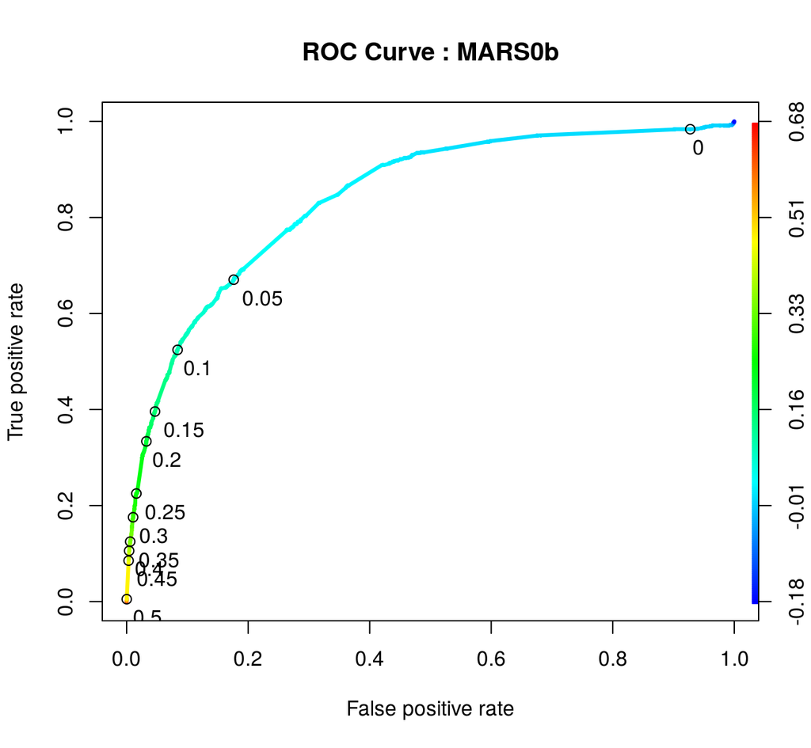

```r
# cutoffs <- seq(0.0, 1.0, by = 0.1)
cutoffs <- seq(0.0, 0.5, by = 0.05)
t.adj <- c(-0.2, 1.7)
str_title <- paste0("ROC Curve : MARS0b")
plot(MARS0b.perf, main = str_title, lwd = 3, colorize = TRUE, print.cutoffs.at = cutoffs, text.adj = t.adj)
```

```r
# perf_vs_threshold <- list()
perf_vs_threshold <- list(AUC = MARS0b.AUC)
i <- 1
for( threshold in seq(0.05, 0.4, by = 0.05)) {
    i <- i + 1
    this_model <- MARS0b.model
    this_test_data <- MARS0b.test
    this_test_predict <- predict(this_model, type = "response", newdata = this_test_data)

    perf_vs_threshold[[i]] <- prepare_cmat_performance(predicted = this_test_predict,
                                                       threshold = threshold,
                                                       truth = this_test_data$Call_Flag)
    names(perf_vs_threshold)[i] <- paste0("thr_", sprintf("%4.2f", threshold))
    if( i == 2 ) {
        perf_vs_threshold.table <- print_cmat_performance(perf_vs_threshold[[i]], errors = FALSE, extended = flag_ext, direction = "h")
    } else {
        perf_vs_threshold.table <- rbind(perf_vs_threshold.table,
                                         print_cmat_performance(perf_vs_threshold[[i]], errors = FALSE, extended = flag_ext, direction = "h"))
    }
    perf_vs_threshold[[i]]$AUC <- MARS0b.AUC
}
MARS0b.perf_vs_threshold <- perf_vs_threshold
MARS0b.perf_vs_threshold$table <- perf_vs_threshold.table
MARS0b.perf_vs_threshold$table$Threshold <- sprintf("**%.2f**", MARS0b.perf_vs_threshold$table$Threshold)
kable(MARS0b.perf_vs_threshold$table, digits = 3, align = "c", caption = "MARS0b Performance Measures vs. Threshold for Classification")
```

MARS0b Performance Measures vs. Threshold for Classification

| Threshold | Accuracy | Sensitivity | Specificity | Precision | NPV | F1 Score |
| --- | --- | --- | --- | --- | --- | --- |
| **0.05** | 0.818 | 0.670 | 0.824 | 0.126 | 0.985 | 0.212 |
| **0.10** | 0.902 | 0.524 | 0.916 | 0.192 | 0.981 | 0.281 |
| **0.15** | 0.933 | 0.396 | 0.953 | 0.244 | 0.977 | 0.302 |
| **0.20** | 0.944 | 0.334 | 0.967 | 0.280 | 0.975 | 0.305 |
| **0.25** | 0.956 | 0.225 | 0.984 | 0.347 | 0.971 | 0.273 |
| **0.30** | 0.960 | 0.176 | 0.989 | 0.385 | 0.969 | 0.241 |
| **0.35** | 0.962 | 0.125 | 0.994 | 0.447 | 0.968 | 0.195 |
| **0.40** | 0.963 | 0.105 | 0.996 | 0.490 | 0.967 | 0.173 |

# MARS w/ `data1`

We fit `data1` using R’s `earth()` function. The summary is shown below.

```r
MARS1.train <- data1.train
MARS1.test <-  data1.test

# MARS wants factors
MARS1.train$Call_Flag <- ifelse(MARS1.train$Call_Flag, "YES", "NO") %>% factor( . )
MARS1.test$Call_Flag  <- ifelse(MARS1.test$Call_Flag, "YES", "NO") %>% factor( . )

MARS1.train$MART_STATUS <- factor(MARS1.train$MART_STATUS)
MARS1.test$MART_STATUS <- factor(MARS1.test$MART_STATUS)
MARS1.train$GENDER <- factor(MARS1.train$GENDER)
MARS1.test$GENDER <- factor(MARS1.test$GENDER)
MARS1.train$CustomerSegment <- factor(MARS1.train$CustomerSegment)
MARS1.test$CustomerSegment <- factor(MARS1.test$CustomerSegment)
```

```r
MARS1.model <- earth(Call_Flag ~ ., data = MARS1.train, degree = 2, nfold = 5, ncross = 6, keepxy = TRUE)
```

```r
summary(MARS1.model)
# Call: earth(formula=Call_Flag~., data=MARS1.train, keepxy=TRUE, ncross=6, nfold=5, degree=2)
#
#                                          coefficients
# (Intercept)                               0.224472576
# h(5-CHANNEL1_3M)                         -0.019083613
# h(1-CHANNEL4_3M)                         -0.057052603
# h(CHANNEL4_3M-1)                          0.080263125
# h(1-PAYMENTS_3M)                          0.048476719
# h(PAYMENTS_3M-1)                         -0.034745701
# h(CHANNEL4_3M-1) * RECENT_PAYMENT        -0.081331008
# h(1-PAYMENTS_3M) * POLICYPURCHASECHANNEL -0.056830871
# h(1-CHANNEL2_3M) * h(1-CHANNEL4_3M)      -0.029588997
# h(1-CHANNEL4_3M) * h(PAYMENTS_3M-2)       0.030183232
# h(1-CHANNEL4_3M) * h(2-PAYMENTS_3M)      -0.018535324
# h(CHANNEL4_3M-1) * h(EVENT2_90_SUM-1)    -0.009009357
# h(CHANNEL4_3M-1) * h(1-EVENT2_90_SUM)     0.085868913
# h(1-PAYMENTS_3M) * h(1-LOGINS)            0.051185276
#
# Selected 14 of 17 terms, and 8 of 23 predictors
# Termination condition: RSq changed by less than 0.001 at 17 terms
# Importance: CHANNEL4_3M, EVENT2_90_SUM, PAYMENTS_3M, LOGINS, CHANNEL2_3M, RECENT_PAYMENT, ...
# Number of terms at each degree of interaction: 1 5 8
# GCV 0.03166512  RSS 2863.382  GRSq 0.1009189  RSq 0.1015646  CVRSq 0.1006962
#
# Note: the cross-validation sd's below are standard deviations across folds
#
# Cross validation:   nterms 15.27 sd 1.74    nvars 8.63 sd 0.81
#
#      CVRSq    sd     ClassRate sd     MaxErr    sd
#        0.1 0.007          0.96  0        1.2 0.037
```

#### Important Variables

```r
ev <- evimp(MARS1.model)
tmp.df <- data.frame(nsubsets = ev[, 3], gcv = ev[, 4], rss = ev[, 6])
row.names(tmp.df) <- sprintf('**%s**', row.names(tmp.df))
```

Important Variables (based on CV)

|  | nsubsets | gcv | rss |
| --- | --- | --- | --- |
| **CHANNEL4_3M** | 13 | 100.00 | 100.00 |
| **EVENT2_90_SUM** | 13 | 100.00 | 100.00 |
| **PAYMENTS_3M** | 12 | 63.77 | 64.02 |
| **LOGINS** | 12 | 63.77 | 64.02 |
| **CHANNEL2_3M** | 11 | 55.15 | 55.45 |
| **RECENT_PAYMENT** | 9 | 40.62 | 41.02 |
| **CHANNEL1_3M** | 7 | 29.16 | 29.65 |
| **POLICYPURCHASECHANNEL** | 4 | 12.73 | 13.44 |

### Prediction on Test set

Setting a **threshold** on the response at **0.2**

```r
MARS1.test.predict <- predict(MARS1.model, newdata = MARS1.test, type = "response")

MARS1.test.performance <- prepare_cmat_performance(predicted = MARS1.test.predict > MARS1.threshold, truth = MARS1.test$Call_Flag)
MARS1.test.cmat <- MARS1.test.performance$cmatrix
MARS1.test.accuracy <- MARS1.test.performance$accuracy

MARS1.ROCR_pred_test <- prediction(MARS1.test.predict, MARS1.test$Call_Flag)
MARS1.perf <- performance(MARS1.ROCR_pred_test, "tpr", "fpr")
MARS1.AUC <- as.numeric(performance(MARS1.ROCR_pred_test, "auc")@y.values)

MARS1.test.performance$AUC <- MARS1.AUC
```

- With a threshold at **0.2** the *out-of-sample* confusion matrix for this fit and train/test sets is:

MARS1 Confusion Matrix (threshold = 0.2)

|  | NO | YES |
| --- | --- | --- |
| FALSE | 36622 | 1078 |
| TRUE | 744 | 339 |

The **Area Under the Curve** (**AUC**) for this model on the test data is **0.8279**, which means that our model can differentiate between a randomly selected *retained* and *non-retained* user about **82.79%** of the times.

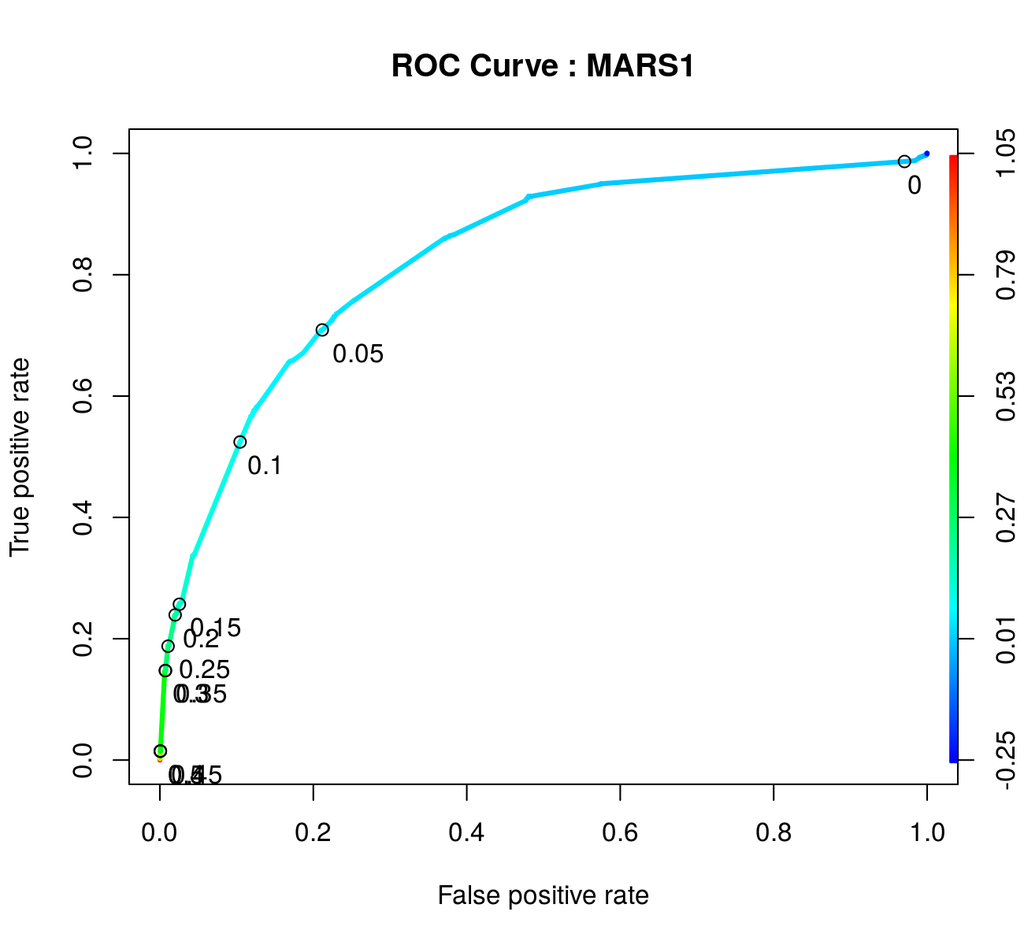

```r
# cutoffs <- seq(0.0, 1.0, by = 0.1)
cutoffs <- seq(0.0, 0.5, by = 0.05)
t.adj <- c(-0.2, 1.7)
str_title <- paste0("ROC Curve : MARS1")
plot(MARS1.perf, main = str_title, lwd = 3, colorize = TRUE, print.cutoffs.at = cutoffs, text.adj = t.adj)
```

```r
# perf_vs_threshold <- list()
perf_vs_threshold <- list(AUC = MARS1.AUC)
i <- 1
for( threshold in seq(0.05, 0.4, by = 0.05)) {
    i <- i + 1
    this_model <- MARS1.model
    this_test_data <- MARS1.test
    this_test_predict <- predict(this_model, type = "response", newdata = this_test_data)

    perf_vs_threshold[[i]] <- prepare_cmat_performance(predicted = this_test_predict,
                                                       threshold = threshold,
                                                       truth = this_test_data$Call_Flag)
    names(perf_vs_threshold)[i] <- paste0("thr_", sprintf("%4.2f", threshold))
    if( i == 2 ) {
        perf_vs_threshold.table <- print_cmat_performance(perf_vs_threshold[[i]], errors = FALSE, extended = flag_ext, direction = "h")
    } else {
        perf_vs_threshold.table <- rbind(perf_vs_threshold.table,
                                         print_cmat_performance(perf_vs_threshold[[i]], errors = FALSE, extended = flag_ext, direction = "h"))
    }
    perf_vs_threshold[[i]]$AUC <- MARS1.AUC
}
MARS1.perf_vs_threshold <- perf_vs_threshold
MARS1.perf_vs_threshold$table <- perf_vs_threshold.table
MARS1.perf_vs_threshold$table$Threshold <- sprintf("**%.2f**", MARS1.perf_vs_threshold$table$Threshold)
kable(MARS1.perf_vs_threshold$table, digits = 3, align = "c", caption = "MARS1 Performance Measures vs. Threshold for Classification")
```

MARS1 Performance Measures vs. Threshold for Classification

| Threshold | Accuracy | Sensitivity | Specificity | Precision | NPV | F1 Score |
| --- | --- | --- | --- | --- | --- | --- |
| **0.05** | 0.786 | 0.709 | 0.789 | 0.113 | 0.986 | 0.195 |
| **0.10** | 0.882 | 0.524 | 0.896 | 0.160 | 0.980 | 0.245 |
| **0.15** | 0.948 | 0.256 | 0.975 | 0.277 | 0.972 | 0.266 |
| **0.20** | 0.953 | 0.239 | 0.980 | 0.313 | 0.971 | 0.271 |
| **0.25** | 0.960 | 0.188 | 0.989 | 0.402 | 0.970 | 0.256 |
| **0.30** | 0.962 | 0.147 | 0.993 | 0.434 | 0.968 | 0.220 |
| **0.35** | 0.962 | 0.147 | 0.993 | 0.441 | 0.968 | 0.221 |
| **0.40** | 0.963 | 0.015 | 0.999 | 0.467 | 0.964 | 0.029 |

# MARS w/ `data2`

We fit `data2` using R’s `earth()` function. The summary is shown below.

```r
MARS2.train <- data2.train
MARS2.test <-  data2.test

# MARS wants factors
MARS2.train$Call_Flag <- ifelse(MARS2.train$Call_Flag, "YES", "NO") %>% factor( . )
MARS2.test$Call_Flag  <- ifelse(MARS2.test$Call_Flag, "YES", "NO") %>% factor( . )

MARS2.train$MART_STATUS <- factor(MARS2.train$MART_STATUS)
MARS2.test$MART_STATUS <- factor(MARS2.test$MART_STATUS)
MARS2.train$GENDER <- factor(MARS2.train$GENDER)
MARS2.test$GENDER <- factor(MARS2.test$GENDER)
MARS2.train$CustomerSegment <- factor(MARS2.train$CustomerSegment)
MARS2.test$CustomerSegment <- factor(MARS2.test$CustomerSegment)
```

```r
MARS2.model <- earth(Call_Flag ~ ., data = MARS2.train, degree = 2, nfold = 5, ncross = 6, keepxy = TRUE)
```

```r
summary(MARS2.model)
# Call: earth(formula=Call_Flag~., data=MARS2.train, keepxy=TRUE, ncross=6, nfold=5, degree=2)
#
#                                       coefficients
# (Intercept)                             0.35534088
# RECENT_PAYMENT                         -0.21539437
# h(CHANNEL1_6M-1)                        0.01120999
# h(6-CHANNEL4_6M)                       -0.05549868
# h(CHANNEL4_6M-6)                       -0.03002742
# h(3-PAYMENTS_6M)                        0.06394553
# h(PAYMENTS_6M-3)                       -0.04131394
# h(1-EVENT2_90_SUM)                      0.00923031
# h(EVENT2_90_SUM-1)                      0.00749161
# h(1-CHANNEL1_6M) * RECENT_PAYMENT      -0.01725902
# h(6-CHANNEL4_6M) * RECENT_PAYMENT       0.03849577
# h(2-CHANNEL2_6M) * h(6-CHANNEL4_6M)    -0.00189034
# h(1-CHANNEL2_6M) * h(3-PAYMENTS_6M)    -0.04010343
# h(CHANNEL2_6M-1) * h(3-PAYMENTS_6M)    -0.03082648
# h(1-CHANNEL4_6M) * h(3-PAYMENTS_6M)    -0.07458203
# h(CHANNEL4_6M-1) * h(3-PAYMENTS_6M)     0.06658052
# h(4-CHANNEL4_6M) * h(PAYMENTS_6M-3)     0.00984763
# h(CHANNEL4_6M-1) * h(1-EVENT2_90_SUM)   0.03513248
# h(3-PAYMENTS_6M) * h(CHANNEL4_3M-1)    -0.12039120
# h(3-PAYMENTS_6M) * h(1-CHANNEL4_3M)     0.06656197
# h(PAYMENTS_6M-3) * h(CHANNEL4_3M-1)     0.00894768
#
# Selected 21 of 26 terms, and 7 of 30 predictors
# Termination condition: RSq changed by less than 0.001 at 26 terms
# Importance: CHANNEL4_6M, PAYMENTS_6M, EVENT2_90_SUM, RECENT_PAYMENT, CHANNEL2_6M, CHANNEL4_3M, ...
# Number of terms at each degree of interaction: 1 8 12
# GCV 0.03071163  RSS 2776.086  GRSq 0.1279918  RSq 0.1289552  CVRSq 0.1226874
#
# Note: the cross-validation sd's below are standard deviations across folds
#
# Cross validation:   nterms 23.03 sd 3.25    nvars 8.03 sd 0.76
#
#      CVRSq    sd     ClassRate sd     MaxErr    sd
#       0.12 0.007          0.96  0        1.4 0.078
```

#### Important Variables

```r
ev <- evimp(MARS2.model)
tmp.df <- data.frame(nsubsets = ev[, 3], gcv = ev[, 4], rss = ev[, 6])
row.names(tmp.df) <- sprintf('**%s**', row.names(tmp.df))
```

MARS2 Important Variables (based on CV)

|  | nsubsets | gcv | rss |
| --- | --- | --- | --- |
| **CHANNEL4_6M** | 20 | 100.00 | 100.00 |
| **PAYMENTS_6M** | 19 | 61.58 | 61.92 |
| **EVENT2_90_SUM** | 18 | 54.08 | 54.50 |
| **RECENT_PAYMENT** | 15 | 39.21 | 39.77 |
| **CHANNEL2_6M** | 15 | 36.28 | 36.91 |
| **CHANNEL4_3M** | 11 | 24.67 | 25.39 |
| **CHANNEL1_6M** | 10 | 20.89 | 21.68 |

### Prediction on Test set

Setting a **threshold** on the response at **0.2**

```r
MARS2.test.predict <- predict(MARS2.model, newdata = MARS2.test, type = "response")

MARS2.test.performance <- prepare_cmat_performance(predicted = MARS2.test.predict > MARS2.threshold, truth = MARS2.test$Call_Flag)
MARS2.test.cmat <- MARS2.test.performance$cmatrix
MARS2.test.accuracy <- MARS2.test.performance$accuracy

MARS2.ROCR_pred_test <- prediction(MARS2.test.predict, MARS2.test$Call_Flag)
MARS2.perf <- performance(MARS2.ROCR_pred_test, "tpr", "fpr")
MARS2.AUC <- as.numeric(performance(MARS2.ROCR_pred_test, "auc")@y.values)

MARS2.test.performance$AUC <- MARS2.AUC
```

- With a threshold at **0.2** the *out-of-sample* confusion matrix for this fit and train/test sets is:

MARS2 Confusion Matrix (threshold = 0.2)

|  | NO | YES |
| --- | --- | --- |
| FALSE | 36169 | 914 |
| TRUE | 1197 | 503 |

The **Area Under the Curve** (**AUC**) for this model on the test data is **0.8516**, which means that our model can differentiate between a randomly selected *retained* and *non-retained* user about **85.16%** of the times.

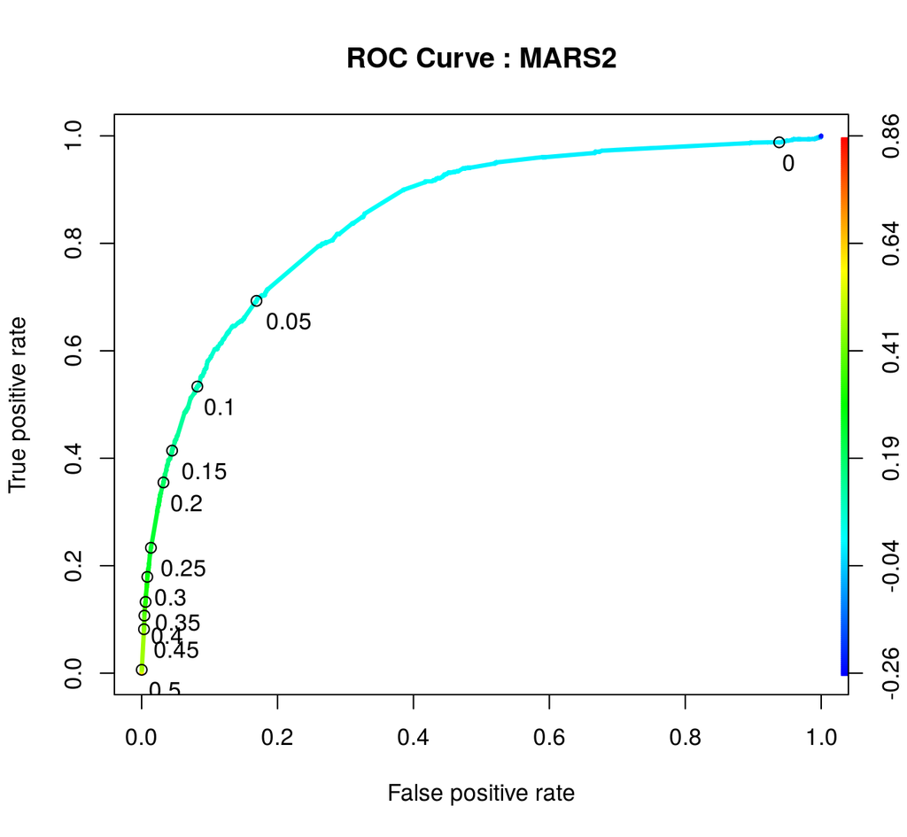

```r
# cutoffs <- seq(0.0, 1.0, by = 0.1)
cutoffs <- seq(0.0, 0.5, by = 0.05)
t.adj <- c(-0.2, 1.7)
str_title <- paste0("ROC Curve : MARS2")
plot(MARS2.perf, main = str_title, lwd = 3, colorize = TRUE, print.cutoffs.at = cutoffs, text.adj = t.adj)
```

```r
# perf_vs_threshold <- list()
perf_vs_threshold <- list(AUC = MARS2.AUC)
i <- 1
for( threshold in seq(0.05, 0.4, by = 0.05)) {
    i <- i + 1
    this_model <- MARS2.model
    this_test_data <- MARS2.test
    this_test_predict <- predict(this_model, type = "response", newdata = this_test_data)

    perf_vs_threshold[[i]] <- prepare_cmat_performance(predicted = this_test_predict,
                                                       threshold = threshold,
                                                       truth = this_test_data$Call_Flag)
    names(perf_vs_threshold)[i] <- paste0("thr_", sprintf("%4.2f", threshold))
    if( i == 2 ) {
        perf_vs_threshold.table <- print_cmat_performance(perf_vs_threshold[[i]], errors = FALSE, extended = flag_ext, direction = "h")
    } else {
        perf_vs_threshold.table <- rbind(perf_vs_threshold.table,
                                         print_cmat_performance(perf_vs_threshold[[i]], errors = FALSE, extended = flag_ext, direction = "h"))
    }
    perf_vs_threshold[[i]]$AUC <- MARS2.AUC
}
MARS2.perf_vs_threshold <- perf_vs_threshold
MARS2.perf_vs_threshold$table <- perf_vs_threshold.table
MARS2.perf_vs_threshold$table$Threshold <- sprintf("**%.2f**", MARS2.perf_vs_threshold$table$Threshold)
kable(MARS2.perf_vs_threshold$table, digits = 3, align = "c", caption = "MARS2 Performance Measures vs. Threshold for Classification")
```

MARS2 Performance Measures vs. Threshold for Classification

| Threshold | Accuracy | Sensitivity | Specificity | Precision | NPV | F1 Score |
| --- | --- | --- | --- | --- | --- | --- |
| **0.05** | 0.826 | 0.693 | 0.831 | 0.135 | 0.986 | 0.225 |
| **0.10** | 0.904 | 0.534 | 0.918 | 0.198 | 0.981 | 0.289 |
| **0.15** | 0.935 | 0.414 | 0.955 | 0.259 | 0.977 | 0.319 |
| **0.20** | 0.946 | 0.355 | 0.968 | 0.296 | 0.975 | 0.323 |
| **0.25** | 0.959 | 0.233 | 0.986 | 0.393 | 0.971 | 0.292 |
| **0.30** | 0.962 | 0.179 | 0.992 | 0.448 | 0.970 | 0.256 |
| **0.35** | 0.963 | 0.133 | 0.994 | 0.464 | 0.968 | 0.206 |
| **0.40** | 0.963 | 0.091 | 0.996 | 0.476 | 0.967 | 0.153 |

# MARS w/ `data3`

We fit `data3` using R’s `earth()` function. The summary is shown below.

```r
MARS3.train <- data3.train
MARS3.test <-  data3.test

# MARS wants factors
MARS3.train$Call_Flag <- ifelse(MARS3.train$Call_Flag, "YES", "NO") %>% factor( . )
MARS3.test$Call_Flag  <- ifelse(MARS3.test$Call_Flag, "YES", "NO") %>% factor( . )

MARS3.train$MART_STATUS <- factor(MARS3.train$MART_STATUS)
MARS3.test$MART_STATUS <- factor(MARS3.test$MART_STATUS)
MARS3.train$GENDER <- factor(MARS3.train$GENDER)
MARS3.test$GENDER <- factor(MARS3.test$GENDER)
MARS3.train$CustomerSegment <- factor(MARS3.train$CustomerSegment)
MARS3.test$CustomerSegment <- factor(MARS3.test$CustomerSegment)
```

```r
MARS3.model <- earth(Call_Flag ~ ., data = MARS3.train, degree = 2, nfold = 5, ncross = 6, keepxy = TRUE)
```

```r
summary(MARS3.model)
# Call: earth(formula=Call_Flag~., data=MARS3.train, keepxy=TRUE, ncross=6, nfold=5, degree=2)
#
#                                       coefficients
# (Intercept)                            0.249724584
# h(CHANNEL1_6M-1)                       0.010597647
# h(6-CHANNEL4_6M)                      -0.036270817
# h(3-PAYMENTS_6M)                       0.018150062
# h(PAYMENTS_6M-3)                      -0.038968941
# h(1-EVENT2_90_SUM)                     0.197974750
# h(1-LOGINS)                            0.031429984
# RECENT_PAYMENT * h(1-LOGINS)          -0.041569613
# h(1-CHANNEL1_6M) * h(Nch_6M-1)        -0.024264398
# h(1-CHANNEL1_6M) * h(1-Nch_6M)         0.012909046
# h(1-CHANNEL2_6M) * h(6-CHANNEL4_6M)   -0.006731843
# h(CHANNEL2_6M-1) * h(6-CHANNEL4_6M)   -0.000639606
# h(1-CHANNEL4_6M) * h(3-PAYMENTS_6M)   -0.057543109
# h(CHANNEL4_6M-1) * h(3-PAYMENTS_6M)    0.071347711
# h(5-CHANNEL4_6M) * h(PAYMENTS_6M-3)    0.007658672
# h(CHANNEL4_6M-5) * h(PAYMENTS_6M-3)    0.003974893
# h(6-CHANNEL4_6M) * h(1-EVENT2_90_SUM) -0.033294486
# h(CHANNEL4_6M-6) * h(1-EVENT2_90_SUM) -0.028455012
# h(3-PAYMENTS_6M) * h(CHANNEL4_3M-1)   -0.156642977
# h(3-PAYMENTS_6M) * h(1-CHANNEL4_3M)    0.056758414
# h(1-CHANNEL4_3M) * h(1-LOGINS)        -0.010214518
# h(CHANNEL4_3M-1) * h(1-LOGINS)         0.033488729
#
# Selected 22 of 26 terms, and 9 of 55 predictors
# Termination condition: RSq changed by less than 0.001 at 26 terms
# Importance: CHANNEL4_6M, PAYMENTS_6M, CHANNEL4_3M, EVENT2_90_SUM, LOGINS, CHANNEL1_6M, ...
# Number of terms at each degree of interaction: 1 6 15
# GCV 0.03099874  RSS 2801.884  GRSq 0.1198397  RSq 0.1208607  CVRSq 0.1194176
#
# Note: the cross-validation sd's below are standard deviations across folds
#
# Cross validation:   nterms 21.40 sd 2.39    nvars 7.77 sd 0.94
#
#      CVRSq    sd     ClassRate sd     MaxErr   sd
#       0.12 0.008          0.96  0        1.3 0.42
```

#### Important Variables

```r
ev <- evimp(MARS3.model)
tmp.df <- data.frame(nsubsets = ev[, 3], gcv = ev[, 4], rss = ev[, 6])
row.names(tmp.df) <- sprintf('**%s**', row.names(tmp.df))
```

MARS3 Important Variables (based on CV)

|  | nsubsets | gcv | rss |
| --- | --- | --- | --- |
| **CHANNEL4_6M** | 21 | 100.00 | 100.00 |
| **PAYMENTS_6M** | 20 | 58.87 | 59.30 |
| **CHANNEL4_3M** | 19 | 53.22 | 53.71 |
| **EVENT2_90_SUM** | 19 | 53.22 | 53.71 |
| **LOGINS** | 14 | 32.23 | 32.95 |
| **CHANNEL1_6M** | 13 | 28.85 | 29.62 |
| **CHANNEL2_6M** | 12 | 25.72 | 26.53 |
| **RECENT_PAYMENT** | 11 | 22.07 | 22.95 |
| **Nch_6M** | 10 | 18.30 | 19.29 |

### Prediction on Test set

Setting a **threshold** on the response at **0.2**

```r
MARS3.test.predict <- predict(MARS3.model, newdata = MARS3.test, type = "response")

MARS3.test.performance <- prepare_cmat_performance(predicted = MARS3.test.predict > MARS3.threshold, truth = MARS3.test$Call_Flag)
MARS3.test.cmat <- MARS3.test.performance$cmatrix
MARS3.test.accuracy <- MARS3.test.performance$accuracy

MARS3.ROCR_pred_test <- prediction(MARS3.test.predict, MARS3.test$Call_Flag)
MARS3.perf <- performance(MARS3.ROCR_pred_test, "tpr", "fpr")
MARS3.AUC <- as.numeric(performance(MARS3.ROCR_pred_test, "auc")@y.values)

MARS3.test.performance$AUC <- MARS3.AUC
```

- With a threshold at **0.2** the *out-of-sample* confusion matrix for this fit and train/test sets is:

MARS3 Confusion Matrix (threshold = 0.2)

|  | NO | YES |
| --- | --- | --- |
| FALSE | 36278 | 909 |
| TRUE | 1088 | 508 |

The **Area Under the Curve** (**AUC**) for this model on the test data is **0.8489**, which means that our model can differentiate between a randomly selected *retained* and *non-retained* user about **84.89%** of the times.

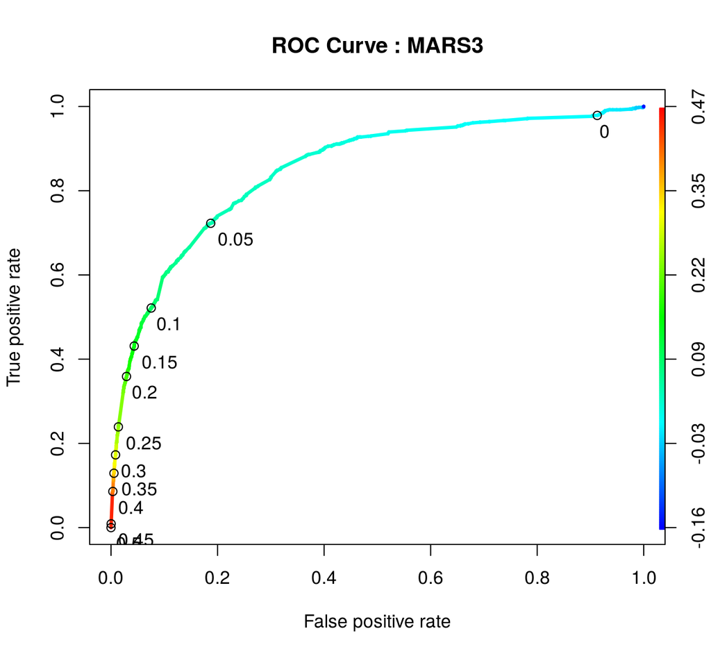

```r
# cutoffs <- seq(0.0, 1.0, by = 0.1)
cutoffs <- seq(0.0, 0.5, by = 0.05)
t.adj <- c(-0.2, 1.7)
str_title <- paste0("ROC Curve : MARS3")
plot(MARS3.perf, main = str_title, lwd = 3, colorize = TRUE, print.cutoffs.at = cutoffs, text.adj = t.adj)
```

```r
# perf_vs_threshold <- list()
perf_vs_threshold <- list(AUC = MARS3.AUC)
i <- 1
for( threshold in seq(0.05, 0.4, by = 0.05)) {
    i <- i + 1
    this_model <- MARS3.model
    this_test_data <- MARS3.test
    this_test_predict <- predict(this_model, type = "response", newdata = this_test_data)

    perf_vs_threshold[[i]] <- prepare_cmat_performance(predicted = this_test_predict,
                                                       threshold = threshold,
                                                       truth = this_test_data$Call_Flag)
    names(perf_vs_threshold)[i] <- paste0("thr_", sprintf("%4.2f", threshold))
    if( i == 2 ) {
        perf_vs_threshold.table <- print_cmat_performance(perf_vs_threshold[[i]], errors = FALSE, extended = flag_ext, direction = "h")
    } else {
        perf_vs_threshold.table <- rbind(perf_vs_threshold.table,
                                         print_cmat_performance(perf_vs_threshold[[i]], errors = FALSE, extended = flag_ext, direction = "h"))
    }
    perf_vs_threshold[[i]]$AUC <- MARS3.AUC
}
MARS3.perf_vs_threshold <- perf_vs_threshold
MARS3.perf_vs_threshold$table <- perf_vs_threshold.table
MARS3.perf_vs_threshold$table$Threshold <- sprintf("**%.2f**", MARS3.perf_vs_threshold$table$Threshold)
kable(MARS3.perf_vs_threshold$table, digits = 3, align = "c", caption = "MARS3 Performance Measures vs. Threshold for Classification")
```

MARS3 Performance Measures vs. Threshold for Classification

| Threshold | Accuracy | Sensitivity | Specificity | Precision | NPV | F1 Score |
| --- | --- | --- | --- | --- | --- | --- |
| **0.05** | 0.810 | 0.723 | 0.813 | 0.128 | 0.987 | 0.217 |
| **0.10** | 0.910 | 0.522 | 0.925 | 0.208 | 0.981 | 0.297 |
| **0.15** | 0.937 | 0.431 | 0.957 | 0.273 | 0.978 | 0.335 |
| **0.20** | 0.949 | 0.359 | 0.971 | 0.318 | 0.976 | 0.337 |
| **0.25** | 0.959 | 0.239 | 0.986 | 0.396 | 0.972 | 0.298 |
| **0.30** | 0.962 | 0.172 | 0.991 | 0.434 | 0.969 | 0.247 |
| **0.35** | 0.963 | 0.129 | 0.995 | 0.472 | 0.968 | 0.203 |
| **0.40** | 0.964 | 0.085 | 0.997 | 0.517 | 0.966 | 0.147 |

# MARS w/ `data4`

```r
MARS4.train <- data4.train
MARS4.test <-  data4.test

# MARS wants factors
MARS4.train$Call_Flag <- ifelse(MARS4.train$Call_Flag, "YES", "NO") %>% factor( . )
MARS4.test$Call_Flag  <- ifelse(MARS4.test$Call_Flag, "YES", "NO") %>% factor( . )

MARS4.train$MART_STATUS <- factor(MARS4.train$MART_STATUS)
MARS4.test$MART_STATUS <- factor(MARS4.test$MART_STATUS)
MARS4.train$GENDER <- factor(MARS4.train$GENDER)
MARS4.test$GENDER <- factor(MARS4.test$GENDER)
MARS4.train$CustomerSegment <- factor(MARS4.train$CustomerSegment)
MARS4.test$CustomerSegment <- factor(MARS4.test$CustomerSegment)
```

```r
MARS4.model <- earth(Call_Flag ~ ., data = MARS4.train, degree = 2, nfold = 5, ncross = 6, keepxy = TRUE)
```

```r
summary(MARS4.model)
# Call: earth(formula=Call_Flag~., data=MARS4.train, keepxy=TRUE, ncross=6, nfold=5, degree=2)
#
#                                       coefficients
# (Intercept)                             0.41764444
# RECENT_PAYMENT                         -0.15655678
# h(5-CHANNEL1_3M)                       -0.03320819
# h(3-CHANNEL4_3M)                       -0.10091403
# h(1-PAYMENTS_3M)                        0.07669295
# h(PAYMENTS_3M-1)                       -0.03272033
# h(1-EVENT2_90_SUM)                      0.18500922
# h(EVENT2_90_SUM-1)                     -0.02148722
# h(1-LOGINS)                             0.02188482
# h(5-CHANNEL1_3M) * RECENT_PAYMENT      -0.00778475
# h(3-CHANNEL4_3M) * RECENT_PAYMENT       0.06398971
# h(3.2115-Tenure) * h(3-CHANNEL4_3M)     0.00234039
# h(Tenure-3.2115) * h(3-CHANNEL4_3M)    -0.00007974
# h(5-CHANNEL1_3M) * h(CHANNEL4_3M-2)     0.00913663
# h(5-CHANNEL1_3M) * h(2-CHANNEL4_3M)     0.00853565
# h(1-CHANNEL2_3M) * h(3-CHANNEL4_3M)    -0.01157465
# h(CHANNEL2_3M-1) * h(3-CHANNEL4_3M)    -0.00239066
# h(2-CHANNEL4_3M) * h(PAYMENTS_3M-1)     0.01375985
# h(3-CHANNEL4_3M) * h(EVENT2_90_SUM-1)   0.01273828
# h(3-CHANNEL4_3M) * h(1-EVENT2_90_SUM)  -0.06165069
# h(1-PAYMENTS_3M) * h(Nch_6M-1)          0.04244265
# h(1-PAYMENTS_3M) * h(1-Nch_6M)         -0.07079309
# h(1-EVENT2_90_SUM) * h(Nch_3M-1)       -0.03636180
# h(1-EVENT2_90_SUM) * h(1-Nch_3M)        0.01328523
#
# Selected 24 of 28 terms, and 10 of 48 predictors
# Termination condition: RSq changed by less than 0.001 at 28 terms
# Importance: CHANNEL4_3M, PAYMENTS_3M, EVENT2_90_SUM, RECENT_PAYMENT, Nch_6M, CHANNEL1_3M, ...
# Number of terms at each degree of interaction: 1 8 15
# GCV 0.03137613  RSS 2835.682  GRSq 0.1091244  RSq 0.1102562  CVRSq 0.09911616
#
# Note: the cross-validation sd's below are standard deviations across folds
#
# Cross validation:   nterms 20.73 sd 2.63    nvars 8.97 sd 1.30
#
#      CVRSq    sd     ClassRate sd     MaxErr sd
#        0.1 0.022          0.96  0       -8.3  2
```

#### Important Variables

```r
ev <- evimp(MARS4.model)
tmp.df <- data.frame(nsubsets = ev[, 3], gcv = ev[, 4], rss = ev[, 6])
row.names(tmp.df) <- sprintf('**%s**', row.names(tmp.df))
```

MARS4 Important Variables (based on CV)

|  | nsubsets | gcv | rss |
| --- | --- | --- | --- |
| **CHANNEL4_3M** | 23 | 100.00 | 100.00 |
| **PAYMENTS_3M** | 22 | 66.87 | 67.25 |
| **EVENT2_90_SUM** | 20 | 55.80 | 56.31 |
| **RECENT_PAYMENT** | 19 | 48.35 | 48.97 |
| **Nch_6M** | 18 | 43.86 | 44.54 |
| **CHANNEL1_3M** | 16 | 36.56 | 37.34 |
| **CHANNEL2_3M** | 13 | 27.37 | 28.27 |
| **Nch_3M** | 12 | 23.69 | 24.67 |
| **LOGINS** | 11 | 19.38 | 20.51 |
| **Tenure** | 10 | 17.10 | 18.27 |

### Prediction on Test set

Setting a **threshold** on the response at **0.2**

```r
MARS4.test.predict <- predict(MARS4.model, newdata = MARS4.test, type = "response")

MARS4.test.performance <- prepare_cmat_performance(predicted = MARS4.test.predict > MARS4.threshold, truth = MARS4.test$Call_Flag)
MARS4.test.cmat <- MARS4.test.performance$cmatrix
MARS4.test.accuracy <- MARS4.test.performance$accuracy

MARS4.ROCR_pred_test <- prediction(MARS4.test.predict, MARS4.test$Call_Flag)
MARS4.perf <- performance(MARS4.ROCR_pred_test, "tpr", "fpr")
MARS4.AUC <- as.numeric(performance(MARS4.ROCR_pred_test, "auc")@y.values)

MARS4.test.performance$AUC <- MARS4.AUC
```

- With a threshold at **0.2** the *out-of-sample* confusion matrix for this fit and train/test sets is:

MARS4 Confusion Matrix (threshold = 0.2)

|  | NO | YES |
| --- | --- | --- |
| FALSE | 36752 | 1123 |
| TRUE | 614 | 294 |

The **Area Under the Curve** (**AUC**) for this model on the test data is **0.8397**, which means that our model can differentiate between a randomly selected *retained* and *non-retained* user about **83.97%** of the times.

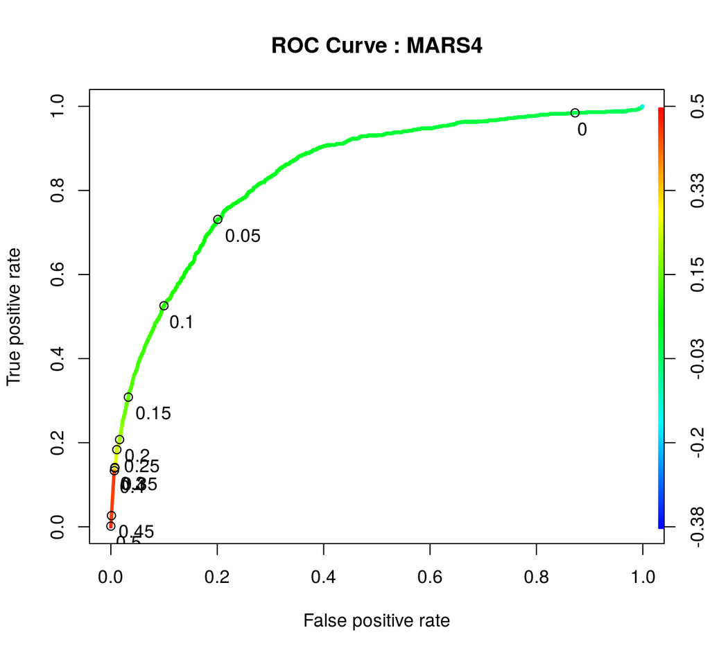

```r
# cutoffs <- seq(0.0, 1.0, by = 0.1)
cutoffs <- seq(0.0, 0.5, by = 0.05)
t.adj <- c(-0.2, 1.7)
str_title <- paste0("ROC Curve : MARS4")
plot(MARS4.perf, main = str_title, lwd = 3, colorize = TRUE, print.cutoffs.at = cutoffs, text.adj = t.adj)
```

```r
perf_vs_threshold <- list(AUC = MARS4.AUC)
i <- 1
for( threshold in seq(0.05, 0.4, by = 0.05)) {
    i <- i + 1
    this_model <- MARS4.model
    this_test_data <- MARS4.test
    this_test_predict <- predict(this_model, type = "response", newdata = this_test_data)

    perf_vs_threshold[[i]] <- prepare_cmat_performance(predicted = this_test_predict,
                                                       threshold = threshold,
                                                       truth = this_test_data$Call_Flag)
    names(perf_vs_threshold)[i] <- paste0("thr_", sprintf("%4.2f", threshold))
    if( i == 2 ) {
        perf_vs_threshold.table <- print_cmat_performance(perf_vs_threshold[[i]], errors = FALSE, extended = flag_ext, direction = "h")
    } else {
        perf_vs_threshold.table <- rbind(perf_vs_threshold.table,
                                         print_cmat_performance(perf_vs_threshold[[i]], errors = FALSE, extended = flag_ext, direction = "h"))
    }
    perf_vs_threshold[[i]]$AUC <- MARS4.AUC
}
MARS4.perf_vs_threshold <- perf_vs_threshold
MARS4.perf_vs_threshold$table <- perf_vs_threshold.table
MARS4.perf_vs_threshold$table$Threshold <- sprintf("**%.2f**", MARS4.perf_vs_threshold$table$Threshold)
kable(MARS4.perf_vs_threshold$table, digits = 3, align = "c", caption = "MARS4 Performance Measures vs. Threshold for Classification")
```

MARS4 Performance Measures vs. Threshold for Classification

| Threshold | Accuracy | Sensitivity | Specificity | Precision | NPV | F1 Score |
| --- | --- | --- | --- | --- | --- | --- |
| **0.05** | 0.796 | 0.731 | 0.799 | 0.121 | 0.987 | 0.208 |
| **0.10** | 0.887 | 0.526 | 0.900 | 0.167 | 0.980 | 0.253 |
| **0.15** | 0.943 | 0.308 | 0.967 | 0.262 | 0.974 | 0.283 |
| **0.20** | 0.955 | 0.207 | 0.984 | 0.324 | 0.970 | 0.253 |
| **0.25** | 0.959 | 0.183 | 0.989 | 0.383 | 0.970 | 0.248 |
| **0.30** | 0.961 | 0.141 | 0.992 | 0.415 | 0.968 | 0.211 |
| **0.35** | 0.961 | 0.140 | 0.993 | 0.415 | 0.968 | 0.209 |
| **0.40** | 0.962 | 0.133 | 0.993 | 0.433 | 0.968 | 0.204 |

# MARS w/ `data5`

```r
MARS5.train <- data5.train
MARS5.test <-  data5.test

# MARS wants factors
MARS5.train$Call_Flag <- ifelse(MARS5.train$Call_Flag, "YES", "NO") %>% factor( . )
MARS5.test$Call_Flag  <- ifelse(MARS5.test$Call_Flag, "YES", "NO") %>% factor( . )

MARS5.train$MART_STATUS <- factor(MARS5.train$MART_STATUS)
MARS5.test$MART_STATUS <- factor(MARS5.test$MART_STATUS)
MARS5.train$GENDER <- factor(MARS5.train$GENDER)
MARS5.test$GENDER <- factor(MARS5.test$GENDER)
MARS5.train$CustomerSegment <- factor(MARS5.train$CustomerSegment)
MARS5.test$CustomerSegment <- factor(MARS5.test$CustomerSegment)
```

```r
MARS5.model <- earth(Call_Flag ~ ., data = MARS5.train, degree = 2, nfold = 5, ncross = 6, keepxy = TRUE)
```

```r
summary(MARS5.model)
# Call: earth(formula=Call_Flag~., data=MARS5.train, keepxy=TRUE, ncross=6, nfold=5, degree=2)
#
#                                       coefficients
# (Intercept)                            0.255966539
# h(CHANNEL1_6M-1)                       0.010965845
# h(6-CHANNEL4_6M)                      -0.042911485
# h(CHANNEL4_6M-6)                      -0.075556359
# h(3-PAYMENTS_6M)                       0.057540146
# h(PAYMENTS_6M-3)                      -0.042159989
# h(1-EVENT2_90_SUM)                     0.014447291
# h(EVENT2_90_SUM-1)                     0.008798509
# h(1-LOGINS)                            0.053403309
# RECENT_PAYMENT * h(1-LOGINS)          -0.040894140
# h(1-CHANNEL2_6M) * h(3-PAYMENTS_6M)   -0.040432851
# h(CHANNEL2_6M-1) * h(3-PAYMENTS_6M)   -0.018726532
# h(1-CHANNEL4_6M) * h(3-PAYMENTS_6M)   -0.072092190
# h(CHANNEL4_6M-1) * h(3-PAYMENTS_6M)    0.037417035
# h(5-CHANNEL4_6M) * h(PAYMENTS_6M-3)    0.008212872
# h(CHANNEL4_6M-5) * h(PAYMENTS_6M-3)    0.005986383
# h(1-CHANNEL4_6M) * h(1-EVENT2_90_SUM) -0.009978318
# h(CHANNEL4_6M-1) * h(1-EVENT2_90_SUM)  0.037745913
# h(3-PAYMENTS_6M) * h(CHANNEL4_3M-1)   -0.107413725
# h(3-PAYMENTS_6M) * h(1-CHANNEL4_3M)    0.067741634
# h(2-CHANNEL4_3M) * h(1-LOGINS)        -0.017699828
# h(CHANNEL4_3M-2) * h(1-LOGINS)         0.044046275
#
# Selected 22 of 24 terms, and 8 of 30 predictors
# Termination condition: RSq changed by less than 0.001 at 24 terms
# Importance: CHANNEL4_6M, PAYMENTS_6M, CHANNEL4_3M, EVENT2_90_SUM, CHANNEL1_6M, LOGINS, ...
# Number of terms at each degree of interaction: 1 8 13
# GCV 0.03100875  RSS 2820.34  GRSq 0.121158  RSq 0.1221711  CVRSq 0.1194468
#
# Note: the cross-validation sd's below are standard deviations across folds
#
# Cross validation:   nterms 22.67 sd 2.88    nvars 8.30 sd 0.79
#
#      CVRSq    sd     ClassRate sd     MaxErr    sd
#       0.12 0.009          0.96  0        1.2 0.054
```

#### Important Variables

```r
ev <- evimp(MARS5.model)
tmp.df <- data.frame(nsubsets = ev[, 3], gcv = ev[, 4], rss = ev[, 6])
row.names(tmp.df) <- sprintf('**%s**', row.names(tmp.df))
```

MARS5 Important Variables (based on CV)

|  | nsubsets | gcv | rss |
| --- | --- | --- | --- |
| **CHANNEL4_6M** | 21 | 100.00 | 100.00 |
| **PAYMENTS_6M** | 20 | 58.97 | 59.39 |
| **CHANNEL4_3M** | 20 | 58.97 | 59.39 |
| **EVENT2_90_SUM** | 19 | 51.54 | 52.05 |
| **CHANNEL1_6M** | 15 | 29.57 | 30.43 |
| **LOGINS** | 14 | 26.19 | 27.12 |
| **RECENT_PAYMENT** | 13 | 22.64 | 23.65 |
| **CHANNEL2_6M** | 12 | 18.92 | 20.05 |

### Prediction on Test set

Setting a **threshold** on the response at **0.2**

```r
MARS5.test.predict <- predict(MARS5.model, newdata = MARS5.test, type = "response")

MARS5.test.performance <- prepare_cmat_performance(predicted = MARS5.test.predict > MARS5.threshold, truth = MARS5.test$Call_Flag)
MARS5.test.cmat <- MARS5.test.performance$cmatrix
MARS5.test.accuracy <- MARS5.test.performance$accuracy

MARS5.ROCR_pred_test <- prediction(MARS5.test.predict, MARS5.test$Call_Flag)
MARS5.perf <- performance(MARS5.ROCR_pred_test, "tpr", "fpr")
MARS5.AUC <- as.numeric(performance(MARS5.ROCR_pred_test, "auc")@y.values)

MARS5.test.performance$AUC <- MARS5.AUC
```

- With a threshold at **0.2** the *out-of-sample* confusion matrix for this fit and train/test sets is:

MARS5 Confusion Matrix (threshold = 0.2)

|  | NO | YES |
| --- | --- | --- |
| FALSE | 36537 | 960 |
| TRUE | 1060 | 469 |

The **Area Under the Curve** (**AUC**) for this model on the test data is **0.8292**, which means that our model can differentiate between a randomly selected *retained* and *non-retained* user about **82.92%** of the times.

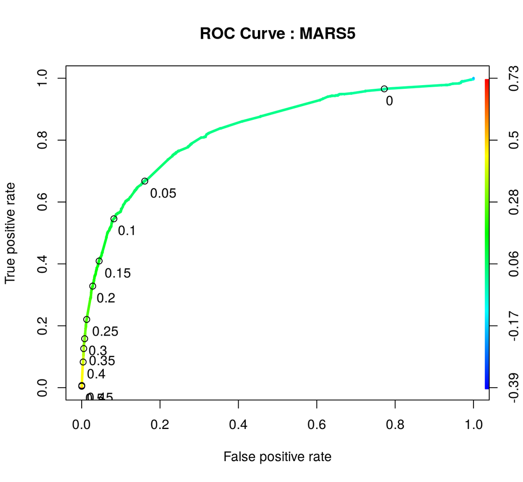

```r
# cutoffs <- seq(0.0, 1.0, by = 0.1)
cutoffs <- seq(0.0, 0.5, by = 0.05)
t.adj <- c(-0.2, 1.7)
str_title <- paste0("ROC Curve : MARS5")
plot(MARS5.perf, main = str_title, lwd = 3, colorize = TRUE, print.cutoffs.at = cutoffs, text.adj = t.adj)
```

```r
perf_vs_threshold <- list(AUC = MARS5.AUC)
i <- 1
for( threshold in seq(0.05, 0.4, by = 0.05)) {
    i <- i + 1
    this_model <- MARS5.model
    this_test_data <- MARS5.test
    this_test_predict <- predict(this_model, type = "response", newdata = this_test_data)

    perf_vs_threshold[[i]] <- prepare_cmat_performance(predicted = this_test_predict,
                                                       threshold = threshold,
                                                       truth = this_test_data$Call_Flag)
    names(perf_vs_threshold)[i] <- paste0("thr_", sprintf("%4.2f", threshold))
    if( i == 2 ) {
        perf_vs_threshold.table <- print_cmat_performance(perf_vs_threshold[[i]], errors = FALSE, extended = flag_ext, direction = "h")
    } else {
        perf_vs_threshold.table <- rbind(perf_vs_threshold.table,
                                         print_cmat_performance(perf_vs_threshold[[i]], errors = FALSE, extended = flag_ext, direction = "h"))
    }
    perf_vs_threshold[[i]]$AUC <- MARS5.AUC
}
MARS5.perf_vs_threshold <- perf_vs_threshold
MARS5.perf_vs_threshold$table <- perf_vs_threshold.table
MARS5.perf_vs_threshold$table$Threshold <- sprintf("**%.2f**", MARS5.perf_vs_threshold$table$Threshold)
kable(MARS5.perf_vs_threshold$table, digits = 3, align = "c", caption = "MARS5 Performance Measures vs. Threshold for Classification")
```

MARS5 Performance Measures vs. Threshold for Classification

| Threshold | Accuracy | Sensitivity | Specificity | Precision | NPV | F1 Score |
| --- | --- | --- | --- | --- | --- | --- |
| **0.05** | 0.833 | 0.668 | 0.839 | 0.136 | 0.985 | 0.226 |
| **0.10** | 0.904 | 0.546 | 0.918 | 0.201 | 0.982 | 0.294 |
| **0.15** | 0.936 | 0.409 | 0.956 | 0.259 | 0.977 | 0.317 |
| **0.20** | 0.948 | 0.328 | 0.972 | 0.307 | 0.974 | 0.317 |
| **0.25** | 0.960 | 0.216 | 0.988 | 0.402 | 0.971 | 0.281 |
| **0.30** | 0.962 | 0.155 | 0.992 | 0.440 | 0.969 | 0.230 |
| **0.35** | 0.963 | 0.120 | 0.995 | 0.474 | 0.967 | 0.191 |
| **0.40** | 0.963 | 0.083 | 0.996 | 0.449 | 0.966 | 0.139 |

# SUMMARY of ALL MARS MODELS

### Performance Measures

Summary of Performance Measures (threshold = 0.1)

|  | Metric | MARS0a | MARS0b | MARS1 | MARS2 | MARS3 | MARS4 | MARS5 |
| --- | --- | --- | --- | --- | --- | --- | --- | --- |
| 1 | AUC | 0.840 | 0.840 | 0.828 | 0.852 | 0.849 | 0.840 | 0.829 |
| 3 | Accuracy | 0.902 | 0.902 | 0.882 | 0.904 | 0.910 | 0.887 | 0.904 |
| 4 | Sensitivity | 0.524 | 0.524 | 0.524 | 0.534 | 0.522 | 0.526 | 0.546 |
| 5 | Specificity | 0.916 | 0.916 | 0.896 | 0.918 | 0.925 | 0.900 | 0.918 |
| 6 | Precision | 0.192 | 0.192 | 0.160 | 0.198 | 0.208 | 0.167 | 0.201 |
| 7 | NPV | 0.981 | 0.981 | 0.980 | 0.981 | 0.981 | 0.980 | 0.982 |
| 8 | F1 Score | 0.281 | 0.281 | 0.245 | 0.289 | 0.297 | 0.253 | 0.294 |

Summary of Performance Measures (threshold = 0.2)

|  | Metric | MARS0a | MARS0b | MARS1 | MARS2 | MARS3 | MARS4 | MARS5 |
| --- | --- | --- | --- | --- | --- | --- | --- | --- |
| 1 | AUC | 0.840 | 0.840 | 0.828 | 0.852 | 0.849 | 0.840 | 0.829 |
| 3 | Accuracy | 0.944 | 0.944 | 0.953 | 0.946 | 0.949 | 0.955 | 0.948 |
| 4 | Sensitivity | 0.334 | 0.334 | 0.239 | 0.355 | 0.359 | 0.207 | 0.328 |
| 5 | Specificity | 0.967 | 0.967 | 0.980 | 0.968 | 0.971 | 0.984 | 0.972 |
| 6 | Precision | 0.280 | 0.280 | 0.313 | 0.296 | 0.318 | 0.324 | 0.307 |
| 7 | NPV | 0.975 | 0.975 | 0.971 | 0.975 | 0.976 | 0.970 | 0.974 |
| 8 | F1 Score | 0.305 | 0.305 | 0.271 | 0.323 | 0.337 | 0.253 | 0.317 |

# APPENDIX

## R Session Info

```r
sessionInfo()
# R version 3.1.3 (2015-03-09)
# Platform: x86_64-pc-linux-gnu (64-bit)
# Running under: Ubuntu 14.04.3 LTS
#
# locale:
#  [1] LC_CTYPE=en_US.UTF-8       LC_NUMERIC=C               LC_TIME=en_US.UTF-8
#  [4] LC_COLLATE=C               LC_MONETARY=en_US.UTF-8    LC_MESSAGES=en_US.UTF-8
#  [7] LC_PAPER=en_US.UTF-8       LC_NAME=C                  LC_ADDRESS=C
# [10] LC_TELEPHONE=C             LC_MEASUREMENT=en_US.UTF-8 LC_IDENTIFICATION=C
#
# attached base packages:
# [1] stats     graphics  grDevices utils     datasets  methods   base
#
# other attached packages:
#  [1] earth_4.3.0       plotmo_3.1.4      TeachingDemos_2.9 plotrix_3.5-12    ROCR_1.0-7
#  [6] gplots_2.17.0     caTools_1.17.1    gridExtra_2.0.0   scales_0.3.0      ggplot2_1.0.1
# [11] lubridate_1.3.3   dplyr_0.4.2       knitr_1.11
#
# loaded via a namespace (and not attached):
#  [1] DBI_0.3.1          KernSmooth_2.23-14 MASS_7.3-43        R6_2.1.1           Rcpp_0.12.0
#  [6] assertthat_0.1     bitops_1.0-6       colorspace_1.2-6   digest_0.6.8       evaluate_0.7.2
# [11] formatR_1.2        gdata_2.17.0       grid_3.1.3         gtable_0.1.2       gtools_3.5.0
# [16] highr_0.5          htmltools_0.2.6    magrittr_1.5       memoise_0.2.1      munsell_0.4.2
# [21] parallel_3.1.3     plyr_1.8.3         proto_0.3-10       reshape2_1.4.1     rmarkdown_0.7
# [26] stringi_0.5-5      stringr_1.0.0      tools_3.1.3        yaml_2.1.13
```